# R Notebook

Carga de las librerias necesarias

```r
library(crafter)
library(dplyr)
library(ggplot2)
library(igraph)
```

Carga la traza (syn_attack.pcap) asociada al ataque de denegacion de servicio

```r
pcap_capture <- read_pcap("syn_attack.pcap")
```

Resumen y estadisticas principales de la traza

```r
# get overall capture summary
summary(pcap_capture)
```

```
File
 Capture file  : syn_attack.pcap
 Filter applied: [none]
 Length        : 34415 bytes

Time
 First packet: 2013-04-24 22:09:30
 Last packet : 2013-04-24 22:10:26

Statistics
 Packets      : 145
 Time span (s): 55.364
 Average pps  : 2.6
```

Informacion de la traza

```r
# high level packet info
pcap_capture_info <- pcap_capture$packet_info()
print(pcap_capture_info)
```

| num | tv_sec | tv_usec | layer_count | protocols | packet_size |
| --- | --- | --- | --- | --- | --- |
| 1 | 1366841370 | 910530 | 4 | Ethernet,IP,RawLayer,TCP | 108 |
| 2 | 1366841370 | 910703 | 4 | Ethernet,IP,RawLayer,TCP | 87 |
| 3 | 1366841370 | 910874 | 3 | Ethernet,IP,TCP | 54 |
| 4 | 1366841371 | 48397 | 4 | Ethernet,IP,RawLayer,TCP | 1440 |
| 5 | 1366841371 | 48456 | 4 | Ethernet,IP,RawLayer,TCP | 492 |
| 6 | 1366841371 | 66329 | 3 | Ethernet,IP,TCP | 54 |
| 7 | 1366841371 | 66888 | 3 | Ethernet,IP,TCP | 54 |
| 8 | 1366841371 | 219749 | 4 | Ethernet,IP,RawLayer,TCP | 105 |
| 9 | 1366841371 | 220002 | 4 | Ethernet,IP,RawLayer,TCP | 108 |
| 10 | 1366841371 | 220092 | 3 | Ethernet,IP,TCP | 54 |

[output cut: 135 more lines]

Informacion asociada a las capas TCP y IP

```r
# retrieve specific layers
# IP
pcap_capture_ip <- pcap_capture$get_layer("IP")
print(pcap_capture_ip)
```

| num | tv_sec | tv_usec | src | dst | protocol_name | size | header_len | total_len | ttl | flags | flag_bits | dscp | frag_ofs |
| --- | --- | --- | --- | --- | --- | --- | --- | --- | --- | --- | --- | --- | --- |
| 1 | 1366841370 | 910530 | 173.194.74.189 | 128.237.255.81 | TCP | 108 | 5 | 94 | 49 | 0 | 000 | 0 | 0 |
| 2 | 1366841370 | 910703 | 173.194.74.189 | 128.237.255.81 | TCP | 87 | 5 | 73 | 49 | 0 | 000 | 0 | 0 |
| 3 | 1366841370 | 910874 | 128.237.255.81 | 173.194.74.189 | TCP | 54 | 5 | 40 | 64 | 2 | 010 | 0 | 0 |
| 4 | 1366841371 | 48397 | 128.237.255.81 | 173.194.74.189 | TCP | 1440 | 5 | 1426 | 64 | 2 | 010 | 0 | 0 |
| 5 | 1366841371 | 48456 | 128.237.255.81 | 173.194.74.189 | TCP | 492 | 5 | 478 | 64 | 2 | 010 | 0 | 0 |
| 6 | 1366841371 | 66329 | 173.194.74.189 | 128.237.255.81 | TCP | 54 | 5 | 40 | 49 | 0 | 000 | 0 | 0 |
| 7 | 1366841371 | 66888 | 173.194.74.189 | 128.237.255.81 | TCP | 54 | 5 | 40 | 49 | 0 | 000 | 0 | 0 |
| 8 | 1366841371 | 219749 | 173.194.74.189 | 128.237.255.81 | TCP | 105 | 5 | 91 | 49 | 0 | 000 | 0 | 0 |
| 9 | 1366841371 | 220002 | 173.194.74.189 | 128.237.255.81 | TCP | 108 | 5 | 94 | 49 | 0 | 000 | 0 | 0 |
| 10 | 1366841371 | 220092 | 128.237.255.81 | 173.194.74.189 | TCP | 54 | 5 | 40 | 64 | 2 | 010 | 0 | 0 |

[output cut: 135 more lines]

```r
# TCP
pcap_capture_tcp <- pcap_capture$get_layer("TCP")
print(pcap_capture_tcp)
```

| num | tv_sec | tv_usec | src | dst | protocol_name | srcport | dstport | seqnum | acknum | headersize | payloadsize | fin | syn | rst | psh | ack | urg | ece | cwr | windowsize | chksum | optsize | payload |
| --- | --- | --- | --- | --- | --- | --- | --- | --- | --- | --- | --- | --- | --- | --- | --- | --- | --- | --- | --- | --- | --- | --- | --- |
| 1 | 1366841370 | 910530 | 173.194.74.189 | 128.237.255.81 | TCP | 443 | 48487 | 2580185829 | 1862420473 | 20 | 54 | FALSE | FALSE | FALSE | TRUE | TRUE | FALSE | FALSE | FALSE | 63756 | 44792 | 0 | \027\003\002 |
| 2 | 1366841370 | 910703 | 173.194.74.189 | 128.237.255.81 | TCP | 443 | 48487 | 2580185883 | 1862420473 | 20 | 33 | FALSE | FALSE | FALSE | TRUE | TRUE | FALSE | FALSE | FALSE | 63756 | 39716 | 0 | \027\003\002 |
| 3 | 1366841370 | 910874 | 128.237.255.81 | 173.194.74.189 | TCP | 48487 | 443 | 1862420473 | 2580185916 | 20 | 0 | FALSE | FALSE | FALSE | FALSE | TRUE | FALSE | FALSE | FALSE | 11792 | 30176 | 0 |  |
| 4 | 1366841371 | 48397 | 128.237.255.81 | 173.194.74.189 | TCP | 48487 | 443 | 1862420473 | 2580185916 | 20 | 1386 | FALSE | FALSE | FALSE | FALSE | TRUE | FALSE | FALSE | FALSE | 11792 | 18194 | 0 | \027\003\002\a\033\xd3\xe2y\xb7\xd3ͪ\027\xaerK`tS\xcf;\xa2\xca\xff\xd4\xcc\xee\x8f\017T%\xa8\025\xa4]z\xe9\xb3F\xd9\030\xea\xf1@\022]\xb2\xd88>"'\xafӷd\x87\xb8*Z\x80e\xcbS\xaf+\020\xba\032\xf6\001r\02… |
| 5 | 1366841371 | 48456 | 128.237.255.81 | 173.194.74.189 | TCP | 48487 | 443 | 1862421859 | 2580185916 | 20 | 438 | FALSE | FALSE | FALSE | TRUE | TRUE | FALSE | FALSE | FALSE | 11792 | 22124 | 0 | \xfe\xf1x\xd3=\xe1\n\xc2\xc6P\xdc\xd3\xfa\xff2\024\xc3\xf2\xe8\x85g\x85>_*"\033\xf0y\xd9\006u\xe1\x9d\xdb`\xc1$\x95\xa1(G\027FH\xe6\x8a\xebW\032\020\xa9\xf0\x94g\xe8\xee$\xa4\022\027\xa7\033\xe8\xa2\x… |
| 6 | 1366841371 | 66329 | 173.194.74.189 | 128.237.255.81 | TCP | 443 | 48487 | 2580185916 | 1862420473 | 20 | 0 | FALSE | FALSE | FALSE | FALSE | TRUE | FALSE | FALSE | FALSE | 63756 | 43747 | 0 |  |
| 7 | 1366841371 | 66888 | 173.194.74.189 | 128.237.255.81 | TCP | 443 | 48487 | 2580185916 | 1862422297 | 20 | 0 | FALSE | FALSE | FALSE | FALSE | TRUE | FALSE | FALSE | FALSE | 62370 | 43309 | 0 |  |
| 8 | 1366841371 | 219749 | 173.194.74.189 | 128.237.255.81 | TCP | 443 | 48487 | 2580185916 | 1862422297 | 20 | 51 | FALSE | FALSE | FALSE | TRUE | TRUE | FALSE | FALSE | FALSE | 63756 | 10578 | 0 | \027\003\002 |
| 9 | 1366841371 | 220002 | 173.194.74.189 | 128.237.255.81 | TCP | 443 | 48487 | 2580185967 | 1862422297 | 20 | 54 | FALSE | FALSE | FALSE | TRUE | TRUE | FALSE | FALSE | FALSE | 63756 | 48375 | 0 | \027\003\002 |
| 10 | 1366841371 | 220092 | 128.237.255.81 | 173.194.74.189 | TCP | 48487 | 443 | 1862422297 | 2580186021 | 20 | 0 | FALSE | FALSE | FALSE | FALSE | TRUE | FALSE | FALSE | FALSE | 11792 | 28247 | 0 |  |

[output cut: 129 more lines]

IP obtenidas al analizar la captura

```r
# get the IPs from the capture
pcap_capture_IPs <- pcap_capture$get_ips("all")
print(pcap_capture_IPs)
```

| ip | n |
| --- | --- |
| 102.146.88.253 | 1 |
| 104.220.68.36 | 1 |
| 115.99.66.210 | 1 |
| 120.130.138.152 | 1 |
| 121.168.84.32 | 1 |
| 128.2.1.10 | 4 |
| 128.237.255.81 | 145 |
| 132.214.137.24 | 1 |
| 132.42.241.177 | 1 |
| 154.29.81.178 | 1 |

[output cut: 28 more lines]

Como se puede ver en la tabla anterior, la IP 128.237.255.81 aparece en mayor numero, de hecho exactamente el numero coincide con el numero de paquetes por lo que se presume que esta es la direccion IP de la maquina que esta siendo atacada.

Grafos entre las IPs

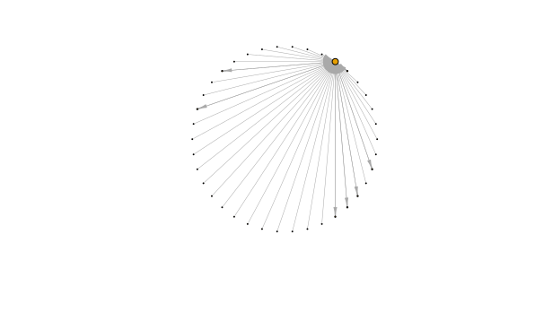

```r
# Pares
pairs <- count(pcap_capture_ip, src, dst, protocol_name)
# Nodos
nodes <- unique(c(pairs$src, pairs$dst))
# Grafo
g <- graph_from_data_frame(pairs, directed=TRUE, vertices=nodes)
# Grafica del grafo
plot(g, layout=layout.circle, vertex.size=sqrt(degree(g)),
     vertex.label=NA, edge.width=0.5, edge.arrow.width=0.5, edge.arrow.size=0.5)
```

Debido a la naturalez del ataque hay muchas IPs distintas por lo tanto es dificil obtener una grafica clara.

Informacion de los primeros 10 paquetes IP y TCP asociados a la traza.

```r
# look at the data
head(pcap_capture_ip, 10)
```

| num | tv_sec | tv_usec | src | dst | protocol_name | size | header_len | total_len | ttl | flags | flag_bits | dscp | frag_ofs |
| --- | --- | --- | --- | --- | --- | --- | --- | --- | --- | --- | --- | --- | --- |
| 1 | 1366841370 | 910530 | 173.194.74.189 | 128.237.255.81 | TCP | 108 | 5 | 94 | 49 | 0 | 000 | 0 | 0 |
| 2 | 1366841370 | 910703 | 173.194.74.189 | 128.237.255.81 | TCP | 87 | 5 | 73 | 49 | 0 | 000 | 0 | 0 |
| 3 | 1366841370 | 910874 | 128.237.255.81 | 173.194.74.189 | TCP | 54 | 5 | 40 | 64 | 2 | 010 | 0 | 0 |
| 4 | 1366841371 | 48397 | 128.237.255.81 | 173.194.74.189 | TCP | 1440 | 5 | 1426 | 64 | 2 | 010 | 0 | 0 |
| 5 | 1366841371 | 48456 | 128.237.255.81 | 173.194.74.189 | TCP | 492 | 5 | 478 | 64 | 2 | 010 | 0 | 0 |
| 6 | 1366841371 | 66329 | 173.194.74.189 | 128.237.255.81 | TCP | 54 | 5 | 40 | 49 | 0 | 000 | 0 | 0 |
| 7 | 1366841371 | 66888 | 173.194.74.189 | 128.237.255.81 | TCP | 54 | 5 | 40 | 49 | 0 | 000 | 0 | 0 |
| 8 | 1366841371 | 219749 | 173.194.74.189 | 128.237.255.81 | TCP | 105 | 5 | 91 | 49 | 0 | 000 | 0 | 0 |
| 9 | 1366841371 | 220002 | 173.194.74.189 | 128.237.255.81 | TCP | 108 | 5 | 94 | 49 | 0 | 000 | 0 | 0 |
| 10 | 1366841371 | 220092 | 128.237.255.81 | 173.194.74.189 | TCP | 54 | 5 | 40 | 64 | 2 | 010 | 0 | 0 |

```r
# look at the TCP layer packets
head(pcap_capture$get_layer("TCP"), 10)
```

| num | tv_sec | tv_usec | src | dst | protocol_name | srcport | dstport | seqnum | acknum | headersize | payloadsize | fin | syn | rst | psh | ack | urg | ece | cwr | windowsize | chksum | optsize | payload |
| --- | --- | --- | --- | --- | --- | --- | --- | --- | --- | --- | --- | --- | --- | --- | --- | --- | --- | --- | --- | --- | --- | --- | --- |
| 1 | 1366841370 | 910530 | 173.194.74.189 | 128.237.255.81 | TCP | 443 | 48487 | 2580185829 | 1862420473 | 20 | 54 | FALSE | FALSE | FALSE | TRUE | TRUE | FALSE | FALSE | FALSE | 63756 | 44792 | 0 | \027\003\002 |
| 2 | 1366841370 | 910703 | 173.194.74.189 | 128.237.255.81 | TCP | 443 | 48487 | 2580185883 | 1862420473 | 20 | 33 | FALSE | FALSE | FALSE | TRUE | TRUE | FALSE | FALSE | FALSE | 63756 | 39716 | 0 | \027\003\002 |
| 3 | 1366841370 | 910874 | 128.237.255.81 | 173.194.74.189 | TCP | 48487 | 443 | 1862420473 | 2580185916 | 20 | 0 | FALSE | FALSE | FALSE | FALSE | TRUE | FALSE | FALSE | FALSE | 11792 | 30176 | 0 |  |
| 4 | 1366841371 | 48397 | 128.237.255.81 | 173.194.74.189 | TCP | 48487 | 443 | 1862420473 | 2580185916 | 20 | 1386 | FALSE | FALSE | FALSE | FALSE | TRUE | FALSE | FALSE | FALSE | 11792 | 18194 | 0 | \027\003\002\a\033\xd3\xe2y\xb7\xd3ͪ\027\xaerK`tS\xcf;\xa2\xca\xff\xd4\xcc\xee\x8f\017T%\xa8\025\xa4]z\xe9\xb3F\xd9\030\xea\xf1@\022]\xb2\xd88>"'\xafӷd\x87\xb8*Z\x80e\xcbS\xaf+\020\xba\032\xf6\001r\02… |
| 5 | 1366841371 | 48456 | 128.237.255.81 | 173.194.74.189 | TCP | 48487 | 443 | 1862421859 | 2580185916 | 20 | 438 | FALSE | FALSE | FALSE | TRUE | TRUE | FALSE | FALSE | FALSE | 11792 | 22124 | 0 | \xfe\xf1x\xd3=\xe1\n\xc2\xc6P\xdc\xd3\xfa\xff2\024\xc3\xf2\xe8\x85g\x85>_*"\033\xf0y\xd9\006u\xe1\x9d\xdb`\xc1$\x95\xa1(G\027FH\xe6\x8a\xebW\032\020\xa9\xf0\x94g\xe8\xee$\xa4\022\027\xa7\033\xe8\xa2\x… |
| 6 | 1366841371 | 66329 | 173.194.74.189 | 128.237.255.81 | TCP | 443 | 48487 | 2580185916 | 1862420473 | 20 | 0 | FALSE | FALSE | FALSE | FALSE | TRUE | FALSE | FALSE | FALSE | 63756 | 43747 | 0 |  |
| 7 | 1366841371 | 66888 | 173.194.74.189 | 128.237.255.81 | TCP | 443 | 48487 | 2580185916 | 1862422297 | 20 | 0 | FALSE | FALSE | FALSE | FALSE | TRUE | FALSE | FALSE | FALSE | 62370 | 43309 | 0 |  |
| 8 | 1366841371 | 219749 | 173.194.74.189 | 128.237.255.81 | TCP | 443 | 48487 | 2580185916 | 1862422297 | 20 | 51 | FALSE | FALSE | FALSE | TRUE | TRUE | FALSE | FALSE | FALSE | 63756 | 10578 | 0 | \027\003\002 |
| 9 | 1366841371 | 220002 | 173.194.74.189 | 128.237.255.81 | TCP | 443 | 48487 | 2580185967 | 1862422297 | 20 | 54 | FALSE | FALSE | FALSE | TRUE | TRUE | FALSE | FALSE | FALSE | 63756 | 48375 | 0 | \027\003\002 |
| 10 | 1366841371 | 220092 | 128.237.255.81 | 173.194.74.189 | TCP | 48487 | 443 | 1862422297 | 2580186021 | 20 | 0 | FALSE | FALSE | FALSE | FALSE | TRUE | FALSE | FALSE | FALSE | 11792 | 28247 | 0 |  |

IPs invocradas en todas las trazas

```r
# Obtencion de las IPs involucradas
ips <- unique(c(pcap_capture_ip$src,pcap_capture_ip$dst))
print(ips)
```

```
 [1] "173.194.74.189"  "128.237.255.81"  "74.125.228.86"   "91.189.94.4"
 [5] "199.59.148.147"  "128.2.1.10"      "74.125.228.64"   "121.168.84.32"
 [9] "75.214.206.60"   "21.241.212.197"  "55.53.190.191"   "71.113.17.64"
[13] "120.130.138.152" "171.128.49.99"   "104.220.68.36"   "241.210.41.46"
[17] "33.24.97.48"     "115.99.66.210"   "154.29.81.178"   "69.232.82.51"
[21] "234.183.31.38"   "102.146.88.253"  "196.132.138.81"  "74.125.228.67"
[25] "63.193.172.89"   "16.6.74.206"     "94.148.118.202"  "160.116.210.243"
[29] "248.237.9.18"    "161.147.211.153" "207.137.67.221"  "229.61.253.52"
[33] "180.70.211.154"  "132.214.137.24"  "132.42.241.177"  "65.248.11.247"
[37] "49.201.237.5"    "51.145.58.158"
```

Como se puede ver de la tabla anterior hay un total de 38 direcciones IP diferentes

Tiempos de arribo o lo que sea

```r
# Tiempo de arribo por paquete
start_time = pcap_capture_ip$tv_sec[1] + pcap_capture_ip$tv_usec[1]/1e6
t = (pcap_capture_ip$tv_sec + pcap_capture_ip$tv_usec/1e6) - start_time
t_menos_1 = c(0,t[2:length(t)-1])
dt = t - t_menos_1
tail(t)
```

```
[1] 55.28012 55.35955 55.36357 55.36361 55.36372 55.36375
```

```r
tail(t_menos_1)
```

```
[1] 55.27998 55.28012 55.35955 55.36357 55.36361 55.36372
```

```r
tail(dt)
```

```
[1] 1.399517e-04 7.942891e-02 4.014969e-03 4.100800e-05 1.120567e-04 3.099442e-05
```

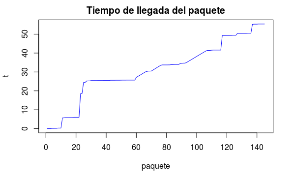

```r
plot(num,t,type="l",col="blue",main="Tiempo de llegada del paquete",xlab = "paquete")
```

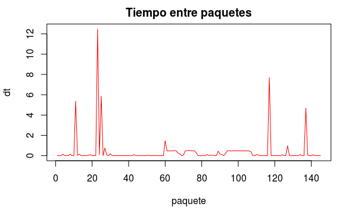

```r
# Ojo con la interpretacion
# punto1: Entre paquete 1 y 2
plot(num,dt,type="l",col="red",main="Tiempo entre paquetes",xlab = "paquete")
```

```r
# Comparacion en diferentes plots
plot(t,type="l",col="blue")
lines(dt, type="l", col="red")
```

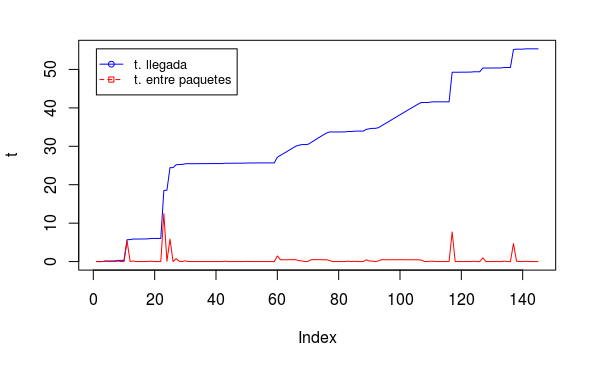

```r
g_range <- range(0, t, dt)
legend(1, g_range[2], c("t. llegada","t. entre paquetes"), cex=0.8, col=c("blue","red"), pch=21:22, lty=1:2);
```

```r
# Comparacion desencajando ejes
plot(num,t,type="l",col="blue",xlab = "paquete")
par(new=TRUE)
```

```r
plot(num,dt,type="l",col="red",xaxt="n",yaxt="n",xlab="",ylab="")
axis(4)
```

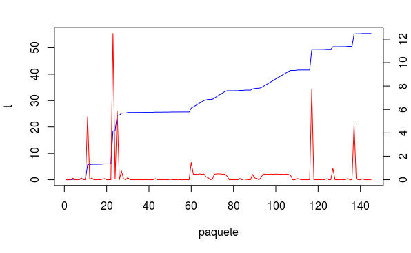

```r
mtext("dt",side=4,line=3)
# Grafica en diferentes ejes
par(mfrow=c(2,1))
```

[figure not shown]

```r
plot(num,t,type="l",col="blue",main="Tiempo de llegada del paquete",xlab = "paquete")
plot(num,dt,type="l",col="red",main="Tiempo entre paquetes",xlab = "paquete")
```

Analizando por encima llegamos a las siguientes conclusiones: 1. Hay momentos especificos en los cuales el tiempo entre paquetes es alto en comparacion con el promedio. Esto se nota en los picos de la grafica roja. 2. Cuando los retardos son mas altos, tambien se nota un incremento brusco en la grafica del tiempo de llegada (o de salida ???) asociado al paquete.

Medidas de estadistica descriptiva

```r
library(psych)
describe(pcap_capture_info$packet_size)
```

```
   vars   n   mean     sd median trimmed mad min  max range skew kurtosis    se
X1    1 145 220.56 374.95     54  112.59   0  54 1440  1386 2.53     5.15 31.14
```

```r
library(pastecs)
describe(pcap_capture_info$packet_size)
```

```
   vars   n   mean     sd median trimmed mad min  max range skew kurtosis    se
X1    1 145 220.56 374.95     54  112.59   0  54 1440  1386 2.53     5.15 31.14
```

```r
library(Hmisc)
describe(pcap_capture_info$packet_size)
```

```
pcap_capture_info$packet_size
       n  missing distinct     Info     Mean      Gmd      .05      .10      .25
     145        0       33    0.855    220.6    280.2     54.0     54.0     54.0
     .50      .75      .90      .95
    54.0    108.0    589.6   1440.0

lowest :   54   58   75   87   90, highest:  821  911 1125 1437 1440
```

Histograma

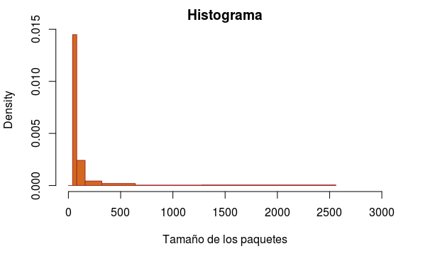

```r
hist(pcap_capture_info$packet_size,
main="Histograma",
xlab="Tamaño de los paquetes",
xlim=c(0,3000),
col="chocolate",
border="brown",
breaks=c(0,20,40,80,160,320,640,1280,2560)
)
```

Informacion tabulada

```r
h <- hist(pcap_capture_info$packet_size,
breaks=c(0,20,40,80,160,320,640,1280,2560)
,plot = FALSE)
print(h)
```

```
$breaks
[1]    0   20   40   80  160  320  640 1280 2560

$counts
[1]  0  0 84 28 10  9  4 10

$density
[1] 0.000000e+00 0.000000e+00 1.448276e-02 2.413793e-03 4.310345e-04 1.939655e-04
[7] 4.310345e-05 5.387931e-05

$mids
[1]   10   30   60  120  240  480  960 1920

$xname
[1] "pcap_capture_info$packet_size"

$equidist
[1] FALSE

attr(,"class")
[1] "histogram"
```

Valores por rango

```r
cont_rangos <- table(cut(pcap_capture_info$packet_size, c(0,20,40,80,160,320,640,1280,2560), include.lowest=TRUE))
print(cont_rangos)
```

```
             [0,20]             (20,40]             (40,80]            (80,160]
                  0                   0                  84                  28
          (160,320]           (320,640]      (640,1.28e+03] (1.28e+03,2.56e+03]
                 10                   9                   4                  10
```

```r
row.names(cont_rangos)
```

```
[1] "[0,20]"              "(20,40]"             "(40,80]"
[4] "(80,160]"            "(160,320]"           "(320,640]"
[7] "(640,1.28e+03]"      "(1.28e+03,2.56e+03]"
```

Grafica aproximada de paquetes por segundos

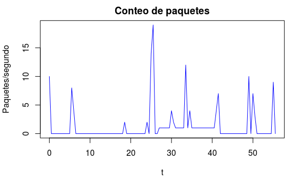

```r
start_time = pcap_capture_ip$tv_sec[1] + pcap_capture_ip$tv_usec[1]/1e6
t = (pcap_capture_ip$tv_sec + pcap_capture_ip$tv_usec/1e6) - start_time
time_divs = seq(0, max(t)+1, by=0.5)
cont_pack_seg = table(cut(t,time_divs,
                      include.lowest=TRUE))
nom_filas=rownames(cont_pack_seg)
valores = as.vector(cont_pack_seg);
plot(time_divs[c(0:length(valores))],valores,type="l",
     col="blue",main="Conteo de paquetes",xlab = "t",ylab="Paquetes/segundo")
```

otro

```r
start_time = pcap_capture_ip$tv_sec[1] + pcap_capture_ip$tv_usec[1]/1e6
t = (pcap_capture_ip$tv_sec + pcap_capture_ip$tv_usec/1e6) - start_time
time_divs = seq(0, max(t)+1, by=1)
cont_pack_seg = table(cut(t,time_divs,
                      include.lowest=TRUE))
nom_filas=rownames(cont_pack_seg)
valores = as.vector(cont_pack_seg);
plot(time_divs[c(0:length(valores))],valores,type="l",
     col="blue",main="Conteo de paquetes",xlab = "t",ylab="Paquetes/segundo",
     xlim=c(0, max(time_divs)),
     ylim=c(0, max(valores)),axes = FALSE, panel.first = grid())
axis(1, at = seq(0,max(time_divs),2))                  # x-Axis
```

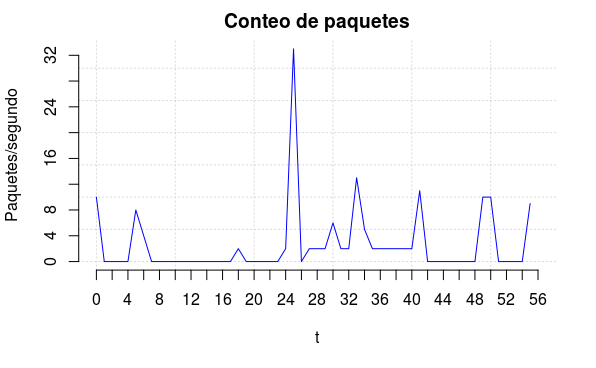

```r
axis(2, at = seq(0,max(valores),4))                    # y-Axis
```